# Dietary-Restriction Restaurants in New Orleans

- Show All Code
- Hide All Code
- View Source

Steps 3–6: categories, reviews, spatial joins, and geographic choice

Author

Adithi Vuligonda

Published

November 10, 2026

## 1 Research question

Where in New Orleans can someone with dietary restrictions find the best halal, vegetarian, and vegan restaurants, and which geographic area is most useful for finding them?

## 2 Data

```r
business <- readRDS("data/new_orleans/business_new_orleans.rds")
reviews  <- readRDS("data/new_orleans/reviews_new_orleans.rds")
cat("Restaurants:", nrow(business), "| Reviews:", nrow(reviews), "\n")
```

```
Restaurants: 2259 | Reviews: 476421
```

The business file contains 2,259 New Orleans restaurants and the review file contains 476,421 reviews for those restaurants. The raw Yelp JSON files were processed in chunks during Steps 1–2 and are not required for this report.

## 3 Step 3: Selecting related categories

I selected `halal`, `vegetarian`, and `vegan` because all three describe dietary options that can help a diner with dietary restrictions choose a restaurant. They are related, but they are not interchangeable: halal is a religious dietary standard, while vegetarian and vegan describe food restrictions. A restaurant qualifies if it matches **at least one** selected Yelp category.

```r
restaurant_categories <- business |>
  select(business_id, business_name, categories) |>
  separate_rows(categories, sep = ",") |>
  mutate(category = str_squish(str_to_lower(categories))) |>
  filter(category != "") |>
  distinct(business_id, business_name, category)

category_counts <- restaurant_categories |> count(category, sort = TRUE)
category_counts |> filter(category %in% c("halal", "vegetarian", "vegan"))
```

```
# A tibble: 3 × 2
  category       n
  <chr>      <int>
1 vegetarian    70
2 vegan         68
3 halal         11
```

The selected categories occur on 11 halal, 70 vegetarian, and 68 vegan business records. Because a business may have more than one label, these counts should not be added together to estimate the number of restaurants.

```r
selected_categories <- c("halal", "vegetarian", "vegan")

selected_ids <- restaurant_categories |>
  filter(category %in% selected_categories) |>
  distinct(business_id)

selected_category_rows <- restaurant_categories |>
  filter(category %in% selected_categories)

selected_restaurants <- business |>
  semi_join(selected_ids, by = "business_id") |>
  filter(!is.na(latitude), !is.na(longitude))

pair_counts <- inner_join(
  selected_category_rows,
  selected_category_rows,
  by = c("business_id", "business_name"),
  suffix = c("_a", "_b"),
  relationship = "many-to-many"
) |>
  filter(category_a < category_b) |>
  count(category_a, category_b, sort = TRUE)

pair_counts
```

```
# A tibble: 3 × 3
  category_a category_b     n
  <chr>      <chr>      <int>
1 vegan      vegetarian    21
2 halal      vegetarian     3
3 halal      vegan          1
```

```r
cat("Qualifying restaurants:", nrow(selected_restaurants), "\n")
```

```
Qualifying restaurants: 125
```

There are **125 qualifying restaurants**. The strongest overlap is between vegan and vegetarian (21 businesses). Three businesses are both halal and vegetarian, and one is both halal and vegan. Thus, the inclusion rule broadens the analysis to restaurants offering any of the three options while still allowing overlap to be reported transparently.

## 4 Step 4: Joining businesses to reviews

```r
selected_reviews <- reviews |>
  semi_join(selected_restaurants, by = "business_id") |>
  mutate(review_date = as.Date(date), review_year = lubridate::year(review_date))

business_review_summary <- selected_reviews |>
  group_by(business_id) |>
  summarise(
    reviews_in_file = n(),
    avg_review_stars = mean(stars, na.rm = TRUE),
    .groups = "drop"
  )

selected_restaurants <- selected_restaurants |>
  left_join(business_review_summary, by = "business_id")

selected_reviews |>
  summarise(
    reviews = n(),
    restaurants = n_distinct(business_id),
    reviewers = n_distinct(user_id)
  )
```

```
# A tibble: 1 × 3
  reviews restaurants reviewers
    <int>       <int>     <int>
1   29334         125     22665
```

Filtering before the join leaves **29,334 reviews** from **22,665 reviewers** for the 125 selected restaurants. The restaurant-level review average is an ordinary mean across all available reviews; it is not a reviewer-normalized score, because reviewer normalization is part of Step 7.

## 5 Step 5: Official city boundary

```r
make_points <- function(df) {
  st_as_sf(df, coords = c("longitude", "latitude"), crs = 4326,
           remove = FALSE) |>
    st_transform(crs_m)
}

louisiana_places <- tigris::places(state = "LA", cb = TRUE, year = 2024) |>
  st_make_valid() |>
  st_transform(crs_m)

all_points <- make_points(filter(business, !is.na(latitude), !is.na(longitude)))

restaurants_with_place <- all_points |>
  st_join(louisiana_places |> select(place_geoid = GEOID,
                                     place_name = NAME),
          join = st_within, left = TRUE) |>
  distinct(business_id, .keep_all = TRUE)

city_vs_place <- restaurants_with_place |>
  st_drop_geometry() |>
  count(city, place_name, sort = TRUE)
city_vs_place
```

```
# A tibble: 11 × 3
   city        place_name      n
   <chr>       <chr>       <int>
 1 New Orleans New Orleans  2202
 2 New Orleans Elmwood        18
 3 New Orleans Jefferson      13
 4 New Orleans Harahan        10
 5 New Orleans Terrytown       4
 6 New Orleans Metairie        3
 7 New Orleans River Ridge     3
 8 New Orleans Arabi           2
 9 New Orleans Harvey          2
10 New Orleans Gretna          1
11 New Orleans Kenner          1
```

```r
mismatches <- restaurants_with_place |>
  st_drop_geometry() |>
  filter(is.na(place_name) | place_name != "New Orleans") |>
  select(business_name, address, postal_code, place_name, latitude, longitude)

cat("Restaurants labeled New Orleans but outside the official polygon:",
    nrow(mismatches), "\n")
```

```
Restaurants labeled New Orleans but outside the official polygon: 57
```

```r
head(mismatches, 10)
```

```
# A tibble: 10 × 6
   business_name               address postal_code place_name latitude longitude
   <chr>                       <chr>   <chr>       <chr>         <dbl>     <dbl>
 1 Calypso Restaurant          "10210… 70123       River Rid…     30.0     -90.2
 2 Sake Cafe of Elmwood        "1130 … 70123       Elmwood        30.0     -90.2
 3 Dots Diner                  "2317 … 70121       Jefferson      30.0     -90.2
 4 Hong Kong Kitchen           "1820 … 70123       Harahan        30.0     -90.2
 5 Taylor Made Wings On The G… ""      70032       Arabi          30.0     -90.0
 6 Joe Sepie's                 "4402 … 70121       Jefferson      30.0     -90.2
 7 New Orleans Hamburger & Se… "1005 … 70121       Elmwood        30.0     -90.2
 8 Seersucker Restaurant & Ca… "938 H… 70053       Gretna         29.9     -90.0
 9 Crabby Jack's               "428 J… 70121       Jefferson      30.0     -90.1
10 Danny & Clydes Food Store   "5861 … 70123       Elmwood        30.0     -90.2
```

The spatial join identifies **2,202** businesses whose Yelp city label and official place are both New Orleans. It identifies **57 mismatches**. The mismatches are concentrated in nearby places such as Elmwood, Jefferson, and Harahan, with some businesses in Gretna, Terrytown, and other neighboring communities. This pattern suggests that Yelp’s `city` field often reflects a postal or marketing address rather than the municipal polygon containing the coordinates. I retain the Yelp-defined New Orleans restaurant set for the main analysis, but report this boundary limitation rather than silently deleting the mismatches.

[figure not shown]

```r
nola_boundary <- louisiana_places |> filter(NAME == "New Orleans")
nola_points <- filter(restaurants_with_place, place_name == "New Orleans")

ggplot() +
  geom_sf(data = nola_boundary, fill = "grey95", color = "grey35") +
  geom_sf(data = nola_points, aes(color = stars), alpha = 0.6, size = 1) +
  scale_color_viridis_c(option = "C", limits = c(1, 5)) +
  labs(title = "Yelp restaurants located within New Orleans",
       color = "Business\nstars") +
  theme_minimal()
```

## 6 Step 6: Choose and defend a geographic area

### 6.1 Comparing geographic systems

I compare ZIP Code Tabulation Areas, Census tracts, and Census block groups. The Census layers are downloaded through `tigris`; the points are transformed to UTM zone 15N before joining so that all spatial layers use the same projected coordinate system.

```r
zcta_raw <- tigris::zctas(cb = TRUE, starts_with = "70", year = 2020)
zip_col <- intersect(c("ZCTA5CE20", "GEOID20", "ZCTA5CE10", "GEOID10", "GEOID"),
                     names(zcta_raw))[1]
zcta <- zcta_raw |>
  st_make_valid() |> st_transform(crs_m) |>
  transmute(area_id = as.character(.data[[zip_col]]),
            area_name = paste("ZIP", area_id))

tract <- tigris::tracts(state = "LA", county = "Orleans", cb = TRUE, year = 2022) |>
  st_make_valid() |> st_transform(crs_m) |>
  transmute(area_id = GEOID, area_name = paste("Tract", NAME))

block_group <- tigris::block_groups(state = "LA", county = "Orleans", cb = TRUE,
                                    year = 2022) |>
  st_make_valid() |> st_transform(crs_m) |>
  transmute(area_id = GEOID, area_name = paste("Block group", GEOID))

systems <- list("ZIP/ZCTA" = zcta, "Census tract" = tract,
                "Census block group" = block_group)
```

```r
sel_points <- make_points(selected_restaurants)

assign_to_areas <- function(points_sf, boundary_sf) {
  points_sf |>
    st_join(boundary_sf, join = st_within, left = TRUE) |>
    st_drop_geometry() |>
    distinct(business_id, .keep_all = TRUE)
}

summarise_areas <- function(assigned) {
  assigned |>
    filter(!is.na(area_id)) |>
    group_by(area_id, area_name) |>
    summarise(
      n_restaurants = n(),
      total_reviews = sum(reviews_in_file, na.rm = TRUE),
      avg_business_stars = mean(stars, na.rm = TRUE),
      avg_review_stars = weighted.mean(avg_review_stars, reviews_in_file,
                                      na.rm = TRUE),
      .groups = "drop"
    )
}

assigned_list <- map(systems, ~ assign_to_areas(sel_points, .x))
area_list <- map(assigned_list, summarise_areas)

comparison <- imap_dfr(assigned_list, function(a, nm) {
  s <- area_list[[nm]]
  tibble(
    `Geographic system` = nm,
    `Areas containing a selected restaurant` = nrow(s),
    `Restaurants assigned` = sum(!is.na(a$area_id)),
    `Unmatched restaurants` = sum(is.na(a$area_id)),
    `Smallest area count` = min(s$n_restaurants),
    `Median area count` = median(s$n_restaurants),
    `Largest area count` = max(s$n_restaurants),
    `Areas with 5+ restaurants` = sum(s$n_restaurants >= 5)
  )
})

knitr::kable(comparison, digits = 2,
             caption = "Comparison of geographic systems")
```

Comparison of geographic systems

| Geographic system | Areas containing a selected restaurant | Restaurants assigned | Unmatched restaurants | Smallest area count | Median area count | Largest area count | Areas with 5+ restaurants |
| --- | --- | --- | --- | --- | --- | --- | --- |
| ZIP/ZCTA | 12 | 125 | 0 | 1 | 11 | 26 | 8 |
| Census tract | 47 | 124 | 1 | 1 | 2 | 24 | 4 |
| Census block group | 64 | 124 | 1 | 1 | 1 | 10 | 4 |

```r
write_csv(comparison, "figures/geography_comparison.csv")
```

The resulting comparison is:

| Geographic system | Areas | Assigned | Unmatched | Smallest | Median | Largest | Areas with 5+ |
| --- | --- | --- | --- | --- | --- | --- | --- |
| ZIP/ZCTA | 12 | 125 | 0 | 1 | 11 | 26 | 8 |
| Census tract | 47 | 124 | 1 | 1 | 2 | 24 | 4 |
| Census block group | 64 | 124 | 1 | 1 | 1 | 10 | 4 |

ZIP/ZCTAs provide the clearest comparison for this question. They are familiar to a general audience, have no unmatched selected restaurants, and concentrate the restaurants into 12 areas, including eight with at least five restaurants. The tract and block-group systems provide more geographic detail, but most areas contain only one or two selected restaurants. Their apparent top ratings would therefore be more sensitive to individual businesses and small samples.

```r
area_list[["ZIP/ZCTA"]] |>
  filter(n_restaurants >= 5) |>
  arrange(desc(avg_review_stars)) |>
  select(area_name, n_restaurants, total_reviews,
         avg_business_stars, avg_review_stars) |>
  knitr::kable(digits = 2,
    caption = "ZIP/ZCTA areas with at least five selected restaurants")
```

ZIP/ZCTA areas with at least five selected restaurants

| area_name | n_restaurants | total_reviews | avg_business_stars | avg_review_stars |
| --- | --- | --- | --- | --- |
| ZIP 70112 | 11 | 4252 | 4.18 | 4.41 |
| ZIP 70113 | 6 | 687 | 4.42 | 4.40 |
| ZIP 70118 | 11 | 3764 | 4.09 | 4.33 |
| ZIP 70117 | 15 | 1509 | 4.40 | 4.25 |
| ZIP 70119 | 19 | 2161 | 4.16 | 4.20 |
| ZIP 70115 | 14 | 2613 | 4.00 | 4.15 |
| ZIP 70130 | 26 | 9275 | 4.21 | 4.11 |
| ZIP 70116 | 17 | 4474 | 4.18 | 4.08 |

Among ZIP areas with at least five restaurants, ZIP 70112 has the highest raw average review score (about 4.41), followed closely by ZIP 70113 (about 4.40) and ZIP 70118 (about 4.33). ZIP 70130 has the largest number of qualifying restaurants (26), while ZIP 70116, 70119, 70115, 70112, and 70118 also have substantial numbers of restaurants. This distinction matters: the area with the highest average is not necessarily the area with the greatest choice.

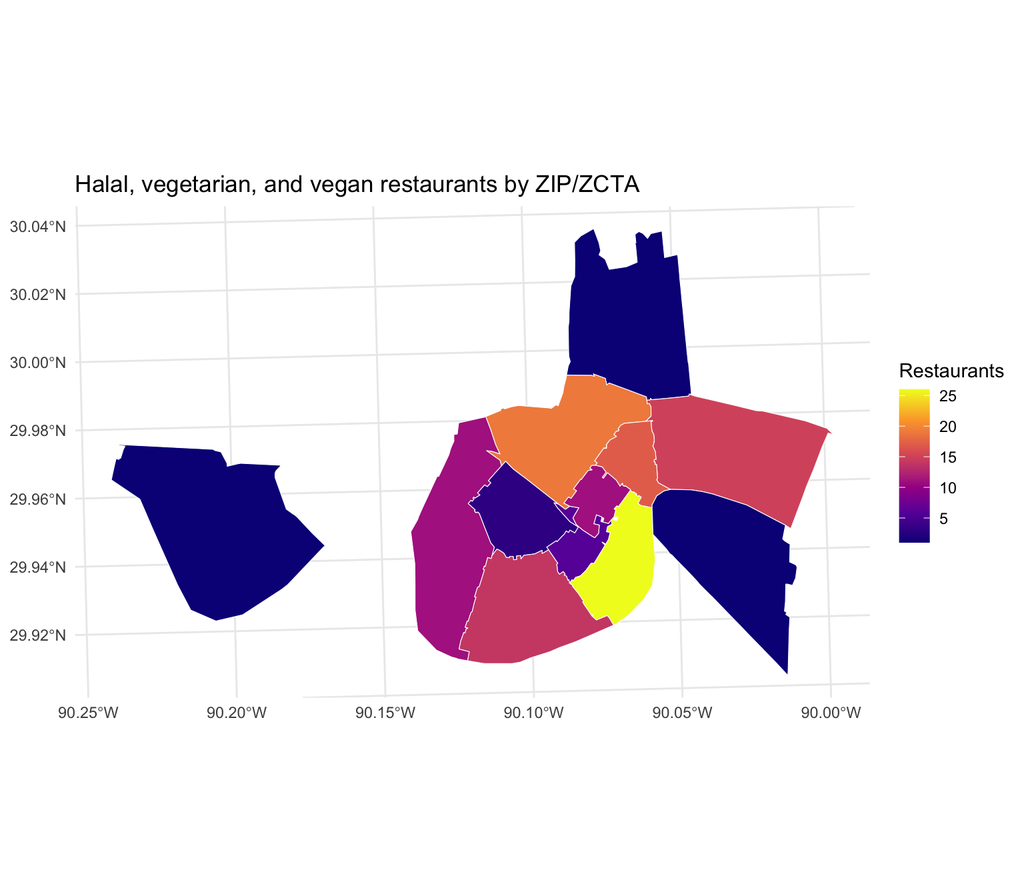

```r
area_map <- zcta |>
  inner_join(area_list[["ZIP/ZCTA"]], by = c("area_id", "area_name"))

ggplot(area_map) +
  geom_sf(aes(fill = n_restaurants), color = "white", linewidth = 0.2) +
  scale_fill_viridis_c(option = "C", na.value = "grey85") +
  labs(title = "Halal, vegetarian, and vegan restaurants by ZIP/ZCTA",
       fill = "Restaurants") +
  theme_minimal()
```

### 6.3 Limitations

The main limitations are that the Yelp categories are user/platform labels and do not independently verify that a restaurant is halal, vegetarian, or vegan. The analysis is also observational: Yelp review volume and ratings may reflect who chooses to review, not only restaurant quality. Several areas have only one or a few restaurants, and the Yelp city label disagrees with the official city polygon for 57 businesses in the full restaurant dataset. Finally, the scores shown here are ordinary review averages and are not adjusted for reviewer scoring habits; reviewer normalization is reserved for Step 7.